# trigonometria-no-circulo-trigonometrico--2

#### $$ \text{---\{ Trigonometria \}---} \\[24pt] $$

### $$ \text{Trigonometria no Círculo Trigonométrico:} \\ \text{O Seno, o Cosseno e a Tangente} $$

$$ \text{Prof. Eduardo Ono} \\[24pt] $$

**Sumário**

- 1. Conceitos e Definições
  - 1.1. Definição. <sub><sup>(Círculo Trigonométrico)</sup></sub>
- 1. Seno
  - 2.1. Definição
  - 2.2. Propriedades
- 1. Cosseno
  - 3.1. Definição
  - 3.2. Propriedades
- 1. Tangente
  - 4.1. Definição
  - 4.2. Propriedades
  - 4.3. Teorema. ($\text{tg }x = \frac{\text{sen }x}{\cos x}$)

# 1. Conceitos e Definições

## 1.1. Definição. <sub><sup>(Círculo Trigonométrico)</sup></sub>

Consideremos sobre um plano um sistema cartesiano ortogonal com origem no ponto $O$. Um **Círculo Trigonométrico** é definido pela circunferência $\lambda$ de raio unitário e centro na origem $O$. O comprimento dessa circnferência é $2\pi$, pois $\,r = 1\,$.

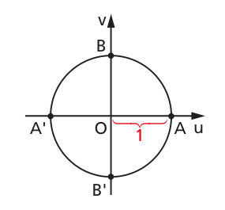

Fonte: Iezzi

A cada número real $x$, com $\,0 \leqslant x < 2\pi\,$, podemos associar a um único ponto $P$ de $\lambda$ do seguinte modo:

1. Se $\,x = 0\,$, então $P$ coincide com $A$;
2. Se $\,x > 0\,$, então realizamos a partir de $A$ um percurso de comprimento $x$, no sentido anti-horário, e marcamos $P$ como ponto final do percurso;
3. Se $\,x < 0\,$, então realizamos a partir de $A$ um percurso de comprimento $|x|$, no sentido horário. O ponto final do percurso é $P$.

# 2. Seno

## 2.1. Definição

Dado um número real $\,x \in [0, 2\pi]\,$, seja $P$ sua imagem no ciclo trigonométrico.

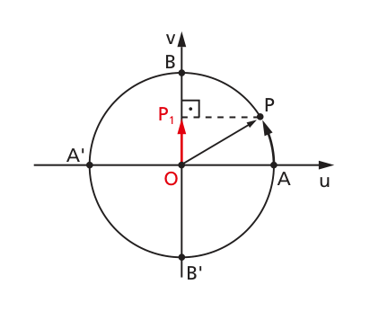

Fonte: Iezzi

Denominamos **seno** de $x$ (e indicamos $\text{sen }x$) a ordenada $\,OP_1\,$ do ponto $P$, onde $\,OP_1\,$ é a projeção ortogonal do ponto $P$ sobre o eixo das ordenadas.

## 2.2. Propriedades

1. Se $x$ é do primeiro ou do segundo quadrante, então $\,\text{sen } x\,$ é positivo.
2. Se $x$ é do terceiro ou do quarto quadrante, então $\,\text{sen } x\,$ é negativo.
3. Se $x$ percorre o primeiro ou o quarto quadrante, então $\,\text{sen } x\,$ é crescente.
4. Se $x$ percorre o segundo ou o terceiro quadrante, então $\,\text{sen } x\,$ é decrescente.

# 3. Cosseno

## 3.1. Definição

Dado um número real $\,x \in [0, 2\pi]\,$, seja $P$ sua imagem no ciclo trigonométrico.

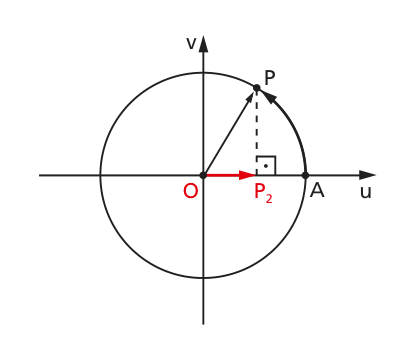

Fonte: Iezzi

Denominamos **cosseno** de $x$ (e indicamos $\cos x$) a abscissa $\,OP_2\,$ do ponto $P$, onde $\,OP_2\,$ é a projeção ortogonal do ponto $P$ sobre o eixo das abscissas.

## 3.2. Propriedades

1. Se $x$ é do primeiro ou do quarto quadrante, então $\,\cos x\,$ é positivo.
2. Se $x$ é do segundo ou do terceiro quadrante, então $\,\cos x\,$ é negativo.
3. Se $x$ percorre o primeiro ou o segundo quadrante, então $\,\cos x\,$ é decrescente.
4. Se $x$ percorre o terceiro ou o quarto quadrante, então $\,\cos x\,$ é crescente.

# 4. Tangente

## 4.1. Definição

Dado um número real $\,x \in [0, 2\pi]\,$, $\,x \neq \cfrac{\pi}{2}\,$ e $\,x \neq \cfrac{3\pi}{2}\,$, seja $P$ sua imagem no ciclo trigonométrico. Consideremos a reta $\,\overleftrightarrow{OP}\,$ e seja T sua interseção com o eixo das tangentes.

Denominamos tangente de $x$ (e indicamos $\text{tg }x$) a medida algébrica do segmento $\,\overline{AT}\,$, copnforme a figura a seguir:

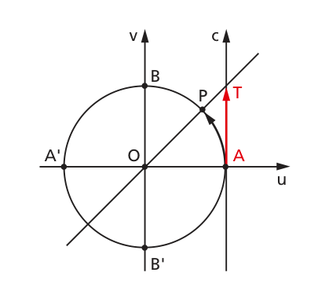

Fonte: Iezzi

Notemos que, para $\,x = \cfrac{\pi}{2}\,$, $P$ está em $B$ e, para $\,x = \cfrac{3\pi}{2}\,$, $P$ está em $B'$, então a reta $\,\overleftrightarrow{OP}\,$ fica paralela ao eixo das tangentes. Como neste caso não existe o ponto $T$, a $\,\text{tg }x\,$ não está definida.

## 4.2. Propriedades

1. Se $x$ é do primeiro ou do terceiro quadrante, então $\,\text{tg }x\,$ é positiva.
2. Se $x$ é do segundo ou do quarto quadrante, então $\,\text{tg }x\,$ é negativa.
3. Se $x$ percorre qualquer um dos quatro quadrantes, então $\,\text{tg }x\,$ é crescente.

## 4.3. Teorema. ($\text{tg }x = \frac{\text{sen }x}{\cos x}$)

Para todo $x$ real, $\,x \in [0, 2\pi]\,$, e $\,x \notin \left\{\cfrac{\pi}{2}, \cfrac{3\pi}{2}\right\}\,$, vale a relação:

$$ \boxed{\ \text{tg }x = \cfrac{\text{sen }x}{\cos x}\ } $$

*Demonstração.*

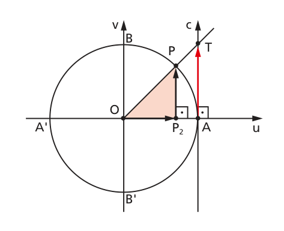

Fonte: Iezzi

a) Se $\,x \notin \{0, \pi, 2\pi\}\,$, a imagem de $x$ é distinta de $A$, $A'$, $B$ e $B'$. Então, temos:

$$ \begin{align*} \triangle OAT &\sim \triangle OP_2P \\ \cfrac{|AT|}{|OA|} &= \cfrac{P_2P}{OP_2} \\ \end{align*} $$$$ \boxed{\ \text{tg }x = \cfrac{\text{sen }x}{\cos x}\ } $$

b) Se $\,x \in \{0, \pi, 2\pi\}\,$, temos:

$$ \boxed{\ \text{tg }x = 0 = \cfrac{\text{sen }x}{\cos x}\ } $$